# Risk Factor Analysis

## Outcome Variable

**Outcome Variable:** whz

## Predictor Variables

**Intervention Variable:** predfeed3

**Adjustment Set:**

- arm
- sex
- month
- brthmon
- W_mage
- meducyrs
- feducyrs
- hhwealth_quart
- hfoodsec
- W_mhtcm
- vagbrth
- W_gagebrth
- W_birthwt
- W_birthlen
- W_nrooms
- W_nchldlt5
- W_parity
- impfloor
- impsan
- safeh20
- delta_W_mage
- delta_meducyrs
- delta_feducyrs
- delta_hhwealth_quart
- delta_hfoodsec
- delta_W_mhtcm
- delta_vagbrth
- delta_W_gagebrth
- delta_W_birthwt
- delta_W_birthlen
- delta_W_nrooms
- delta_W_nchldlt5
- delta_W_parity
- delta_impfloor
- delta_impsan
- delta_safeh20

## Stratifying Variables

The analysis was stratified on these variable(s):

- agecat
- studyid
- country

## Data Summary

| agecat | studyid | country | predfeed3 | n_cell | n |
| --- | --- | --- | --- | --- | --- |
| Birth | ki0047075b-MAL-ED | BANGLADESH | 1 | 193 | 227 |
| Birth | ki0047075b-MAL-ED | BANGLADESH | 0 | 34 | 227 |
| Birth | ki0047075b-MAL-ED | BRAZIL | 1 | 97 | 177 |
| Birth | ki0047075b-MAL-ED | BRAZIL | 0 | 80 | 177 |
| Birth | ki0047075b-MAL-ED | INDIA | 1 | 150 | 193 |
| Birth | ki0047075b-MAL-ED | INDIA | 0 | 43 | 193 |
| Birth | ki0047075b-MAL-ED | NEPAL | 1 | 97 | 166 |
| Birth | ki0047075b-MAL-ED | NEPAL | 0 | 69 | 166 |
| Birth | ki0047075b-MAL-ED | PERU | 1 | 177 | 265 |
| Birth | ki0047075b-MAL-ED | PERU | 0 | 88 | 265 |
| Birth | ki0047075b-MAL-ED | SOUTH AFRICA | 1 | 87 | 231 |
| Birth | ki0047075b-MAL-ED | SOUTH AFRICA | 0 | 144 | 231 |
| Birth | ki0047075b-MAL-ED | TANZANIA, UNITED REPUBLIC OF | 1 | 49 | 114 |
| Birth | ki0047075b-MAL-ED | TANZANIA, UNITED REPUBLIC OF | 0 | 65 | 114 |
| Birth | ki1000109-EE | PAKISTAN | 1 | 1 | 1 |
| Birth | ki1000109-EE | PAKISTAN | 0 | 0 | 1 |
| Birth | kiGH5241-JiVitA-3 | BANGLADESH | 1 | 13739 | 15136 |
| Birth | kiGH5241-JiVitA-3 | BANGLADESH | 0 | 1397 | 15136 |
| Birth | kiGH5241-JiVitA-4 | BANGLADESH | 1 | 28 | 31 |
| Birth | kiGH5241-JiVitA-4 | BANGLADESH | 0 | 3 | 31 |
| 6 months | ki0047075b-MAL-ED | BANGLADESH | 1 | 203 | 237 |
| 6 months | ki0047075b-MAL-ED | BANGLADESH | 0 | 34 | 237 |
| 6 months | ki0047075b-MAL-ED | BRAZIL | 1 | 116 | 209 |
| 6 months | ki0047075b-MAL-ED | BRAZIL | 0 | 93 | 209 |
| 6 months | ki0047075b-MAL-ED | INDIA | 1 | 178 | 233 |
| 6 months | ki0047075b-MAL-ED | INDIA | 0 | 55 | 233 |
| 6 months | ki0047075b-MAL-ED | NEPAL | 1 | 132 | 233 |
| 6 months | ki0047075b-MAL-ED | NEPAL | 0 | 101 | 233 |
| 6 months | ki0047075b-MAL-ED | PERU | 1 | 183 | 270 |
| 6 months | ki0047075b-MAL-ED | PERU | 0 | 87 | 270 |
| 6 months | ki0047075b-MAL-ED | SOUTH AFRICA | 1 | 86 | 248 |
| 6 months | ki0047075b-MAL-ED | SOUTH AFRICA | 0 | 162 | 248 |
| 6 months | ki0047075b-MAL-ED | TANZANIA, UNITED REPUBLIC OF | 1 | 91 | 240 |
| 6 months | ki0047075b-MAL-ED | TANZANIA, UNITED REPUBLIC OF | 0 | 149 | 240 |
| 6 months | ki1000109-EE | PAKISTAN | 1 | 349 | 375 |
| 6 months | ki1000109-EE | PAKISTAN | 0 | 26 | 375 |
| 6 months | ki1113344-GMS-Nepal | NEPAL | 1 | 379 | 458 |
| 6 months | ki1113344-GMS-Nepal | NEPAL | 0 | 79 | 458 |
| 6 months | kiGH5241-JiVitA-3 | BANGLADESH | 1 | 14763 | 16253 |
| 6 months | kiGH5241-JiVitA-3 | BANGLADESH | 0 | 1490 | 16253 |
| 6 months | kiGH5241-JiVitA-4 | BANGLADESH | 1 | 77 | 89 |
| 6 months | kiGH5241-JiVitA-4 | BANGLADESH | 0 | 12 | 89 |
| 24 months | ki0047075b-MAL-ED | BANGLADESH | 1 | 178 | 208 |
| 24 months | ki0047075b-MAL-ED | BANGLADESH | 0 | 30 | 208 |
| 24 months | ki0047075b-MAL-ED | BRAZIL | 1 | 98 | 169 |
| 24 months | ki0047075b-MAL-ED | BRAZIL | 0 | 71 | 169 |
| 24 months | ki0047075b-MAL-ED | INDIA | 1 | 170 | 225 |
| 24 months | ki0047075b-MAL-ED | INDIA | 0 | 55 | 225 |
| 24 months | ki0047075b-MAL-ED | NEPAL | 1 | 128 | 225 |
| 24 months | ki0047075b-MAL-ED | NEPAL | 0 | 97 | 225 |
| 24 months | ki0047075b-MAL-ED | PERU | 1 | 137 | 199 |
| 24 months | ki0047075b-MAL-ED | PERU | 0 | 62 | 199 |
| 24 months | ki0047075b-MAL-ED | SOUTH AFRICA | 1 | 81 | 232 |
| 24 months | ki0047075b-MAL-ED | SOUTH AFRICA | 0 | 151 | 232 |
| 24 months | ki0047075b-MAL-ED | TANZANIA, UNITED REPUBLIC OF | 1 | 79 | 210 |
| 24 months | ki0047075b-MAL-ED | TANZANIA, UNITED REPUBLIC OF | 0 | 131 | 210 |
| 24 months | ki1113344-GMS-Nepal | NEPAL | 1 | 336 | 404 |
| 24 months | ki1113344-GMS-Nepal | NEPAL | 0 | 68 | 404 |
| 24 months | kiGH5241-JiVitA-3 | BANGLADESH | 1 | 7495 | 8313 |
| 24 months | kiGH5241-JiVitA-3 | BANGLADESH | 0 | 818 | 8313 |
| 24 months | kiGH5241-JiVitA-4 | BANGLADESH | 1 | 136 | 151 |
| 24 months | kiGH5241-JiVitA-4 | BANGLADESH | 0 | 15 | 151 |

The following strata were considered:

- agecat: 24 months, studyid: ki0047075b-MAL-ED, country: BANGLADESH
- agecat: 24 months, studyid: ki0047075b-MAL-ED, country: BRAZIL
- agecat: 24 months, studyid: ki0047075b-MAL-ED, country: INDIA
- agecat: 24 months, studyid: ki0047075b-MAL-ED, country: NEPAL
- agecat: 24 months, studyid: ki0047075b-MAL-ED, country: PERU
- agecat: 24 months, studyid: ki0047075b-MAL-ED, country: SOUTH AFRICA
- agecat: 24 months, studyid: ki0047075b-MAL-ED, country: TANZANIA, UNITED REPUBLIC OF
- agecat: 24 months, studyid: ki1113344-GMS-Nepal, country: NEPAL
- agecat: 24 months, studyid: kiGH5241-JiVitA-3, country: BANGLADESH
- agecat: 24 months, studyid: kiGH5241-JiVitA-4, country: BANGLADESH
- agecat: 6 months, studyid: ki0047075b-MAL-ED, country: BANGLADESH
- agecat: 6 months, studyid: ki0047075b-MAL-ED, country: BRAZIL
- agecat: 6 months, studyid: ki0047075b-MAL-ED, country: INDIA
- agecat: 6 months, studyid: ki0047075b-MAL-ED, country: NEPAL
- agecat: 6 months, studyid: ki0047075b-MAL-ED, country: PERU
- agecat: 6 months, studyid: ki0047075b-MAL-ED, country: SOUTH AFRICA
- agecat: 6 months, studyid: ki0047075b-MAL-ED, country: TANZANIA, UNITED REPUBLIC OF
- agecat: 6 months, studyid: ki1000109-EE, country: PAKISTAN
- agecat: 6 months, studyid: ki1113344-GMS-Nepal, country: NEPAL
- agecat: 6 months, studyid: kiGH5241-JiVitA-3, country: BANGLADESH
- agecat: 6 months, studyid: kiGH5241-JiVitA-4, country: BANGLADESH
- agecat: Birth, studyid: ki0047075b-MAL-ED, country: BANGLADESH
- agecat: Birth, studyid: ki0047075b-MAL-ED, country: BRAZIL
- agecat: Birth, studyid: ki0047075b-MAL-ED, country: INDIA
- agecat: Birth, studyid: ki0047075b-MAL-ED, country: NEPAL
- agecat: Birth, studyid: ki0047075b-MAL-ED, country: PERU
- agecat: Birth, studyid: ki0047075b-MAL-ED, country: SOUTH AFRICA
- agecat: Birth, studyid: ki0047075b-MAL-ED, country: TANZANIA, UNITED REPUBLIC OF
- agecat: Birth, studyid: ki1000109-EE, country: PAKISTAN
- agecat: Birth, studyid: kiGH5241-JiVitA-3, country: BANGLADESH
- agecat: Birth, studyid: kiGH5241-JiVitA-4, country: BANGLADESH

### Dropped Strata

Some strata were dropped due to rare outcomes:

- agecat: Birth, studyid: ki1000109-EE, country: PAKISTAN
- agecat: Birth, studyid: kiGH5241-JiVitA-4, country: BANGLADESH

## Methods Detail

We’re interested in the causal parameters $E[Y_a]$ for all values of $a \in \mathcal{A}$. These parameters represent the mean outcome if, possibly contrary to fact, we intervened to set all units to have $A=a$. Under the randomization and positivity assumptions, these are identified by the statistical parameters $\psi_a=E_W[E_{Y|A,W}(Y|A=a,W)]$. In addition, we’re interested in the mean of $Y$, $E[Y]$ under no intervention (the observed mean). We will estimate these parameters by using SuperLearner to fit the relevant likelihood factors – $E_{Y|A,W}(Y|A=a,W)$ and $p(A=a|W)$, and then updating our likelihood fit using a joint TMLE.

For unadjusted analyses ($W=\{\}$), initial likelihoods were estimated using Lrnr_glm to estimate the simple $E(Y|A)$ and Lrnr_mean to estimate $p(A)$. For adjusted analyses, a small library containing Lrnr_glmnet, Lrnr_xgboost, and Lrnr_mean was used.

Having estimated these parameters, we will then use the delta method to estimate relative risks and attributable risks relative to a prespecified baseline level of $A$.

# Results Detail

## Results Plots

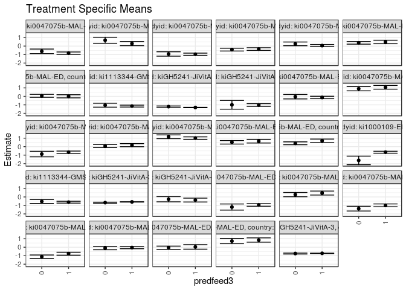

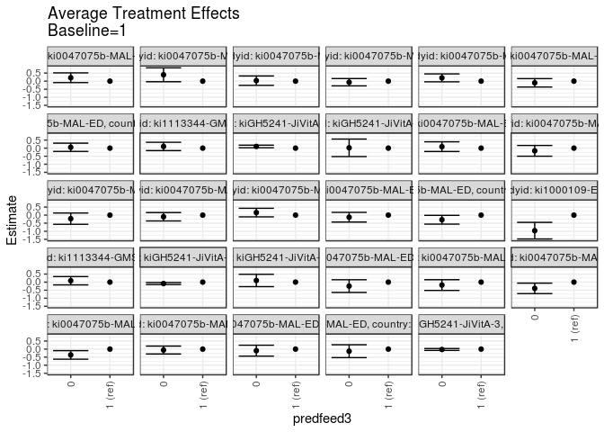

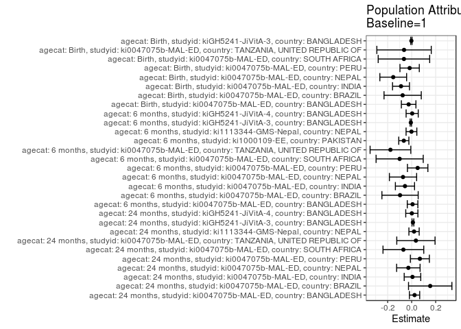

## Results Table

### Parameter: TSM

| agecat | studyid | country | intervention_level | baseline_level | estimate | ci_lower | ci_upper |
| --- | --- | --- | --- | --- | --- | --- | --- |
| Birth | ki0047075b-MAL-ED | BANGLADESH | 1 | NA | -0.9449464 | -1.0968574 | -0.7930354 |
| Birth | ki0047075b-MAL-ED | BANGLADESH | 0 | NA | -1.1917040 | -1.5525845 | -0.8308235 |
| Birth | ki0047075b-MAL-ED | BRAZIL | 1 | NA | 0.4589087 | 0.2236407 | 0.6941766 |
| Birth | ki0047075b-MAL-ED | BRAZIL | 0 | NA | 0.2746151 | 0.0239530 | 0.5252772 |
| Birth | ki0047075b-MAL-ED | INDIA | 1 | NA | -0.9936472 | -1.1599968 | -0.8272976 |
| Birth | ki0047075b-MAL-ED | INDIA | 0 | NA | -1.3822737 | -1.6596994 | -1.1048481 |
| Birth | ki0047075b-MAL-ED | NEPAL | 1 | NA | -0.7648311 | -0.9395585 | -0.5901037 |
| Birth | ki0047075b-MAL-ED | NEPAL | 0 | NA | -1.1251407 | -1.3350850 | -0.9151964 |
| Birth | ki0047075b-MAL-ED | PERU | 1 | NA | -0.0388235 | -0.1762299 | 0.0985829 |
| Birth | ki0047075b-MAL-ED | PERU | 0 | NA | -0.0970709 | -0.3000170 | 0.1058752 |
| Birth | ki0047075b-MAL-ED | SOUTH AFRICA | 1 | NA | 0.0353789 | -0.2294943 | 0.3002520 |
| Birth | ki0047075b-MAL-ED | SOUTH AFRICA | 0 | NA | -0.0623214 | -0.2555174 | 0.1308745 |
| Birth | ki0047075b-MAL-ED | TANZANIA, UNITED REPUBLIC OF | 1 | NA | 0.8500182 | 0.5972018 | 1.1028346 |
| Birth | ki0047075b-MAL-ED | TANZANIA, UNITED REPUBLIC OF | 0 | NA | 0.7200490 | 0.4135877 | 1.0265102 |
| Birth | kiGH5241-JiVitA-3 | BANGLADESH | 1 | NA | -0.7198251 | -0.7405747 | -0.6990755 |
| Birth | kiGH5241-JiVitA-3 | BANGLADESH | 0 | NA | -0.7437664 | -0.8024137 | -0.6851191 |
| 6 months | ki0047075b-MAL-ED | BANGLADESH | 1 | NA | -0.1320077 | -0.2758544 | 0.0118390 |
| 6 months | ki0047075b-MAL-ED | BANGLADESH | 0 | NA | -0.0405499 | -0.3021387 | 0.2210390 |
| 6 months | ki0047075b-MAL-ED | BRAZIL | 1 | NA | 1.0686044 | 0.8506967 | 1.2865121 |
| 6 months | ki0047075b-MAL-ED | BRAZIL | 0 | NA | 0.9017928 | 0.6510993 | 1.1524863 |
| 6 months | ki0047075b-MAL-ED | INDIA | 1 | NA | -0.6546600 | -0.7900852 | -0.5192348 |
| 6 months | ki0047075b-MAL-ED | INDIA | 0 | NA | -0.8743386 | -1.1974236 | -0.5512536 |
| 6 months | ki0047075b-MAL-ED | NEPAL | 1 | NA | 0.1731660 | -0.0089282 | 0.3552602 |
| 6 months | ki0047075b-MAL-ED | NEPAL | 0 | NA | 0.0717498 | -0.1106651 | 0.2541648 |
| 6 months | ki0047075b-MAL-ED | PERU | 1 | NA | 1.0072905 | 0.8602394 | 1.1543416 |
| 6 months | ki0047075b-MAL-ED | PERU | 0 | NA | 1.1652725 | 0.9417185 | 1.3888264 |
| 6 months | ki0047075b-MAL-ED | SOUTH AFRICA | 1 | NA | 0.6436323 | 0.4278045 | 0.8594600 |
| 6 months | ki0047075b-MAL-ED | SOUTH AFRICA | 0 | NA | 0.5133191 | 0.3067558 | 0.7198823 |
| 6 months | ki0047075b-MAL-ED | TANZANIA, UNITED REPUBLIC OF | 1 | NA | 0.6831194 | 0.4726327 | 0.8936061 |
| 6 months | ki0047075b-MAL-ED | TANZANIA, UNITED REPUBLIC OF | 0 | NA | 0.3957587 | 0.2271483 | 0.5643692 |
| 6 months | ki1000109-EE | PAKISTAN | 1 | NA | -0.6563648 | -0.7704698 | -0.5422598 |
| 6 months | ki1000109-EE | PAKISTAN | 0 | NA | -1.6202766 | -2.1225762 | -1.1179771 |
| 6 months | ki1113344-GMS-Nepal | NEPAL | 1 | NA | -0.6175497 | -0.7254366 | -0.5096628 |
| 6 months | ki1113344-GMS-Nepal | NEPAL | 0 | NA | -0.5316435 | -0.7663250 | -0.2969621 |
| 6 months | kiGH5241-JiVitA-3 | BANGLADESH | 1 | NA | -0.5859487 | -0.6067221 | -0.5651752 |
| 6 months | kiGH5241-JiVitA-3 | BANGLADESH | 0 | NA | -0.6740420 | -0.7359017 | -0.6121824 |
| 6 months | kiGH5241-JiVitA-4 | BANGLADESH | 1 | NA | -0.3698924 | -0.5956925 | -0.1440923 |
| 6 months | kiGH5241-JiVitA-4 | BANGLADESH | 0 | NA | -0.2689866 | -0.5769987 | 0.0390255 |
| 24 months | ki0047075b-MAL-ED | BANGLADESH | 1 | NA | -0.8321227 | -0.9679997 | -0.6962456 |
| 24 months | ki0047075b-MAL-ED | BANGLADESH | 0 | NA | -0.6205362 | -0.8892605 | -0.3518119 |
| 24 months | ki0047075b-MAL-ED | BRAZIL | 1 | NA | 0.2922341 | 0.0493466 | 0.5351216 |
| 24 months | ki0047075b-MAL-ED | BRAZIL | 0 | NA | 0.6870639 | 0.3311950 | 1.0429328 |
| 24 months | ki0047075b-MAL-ED | INDIA | 1 | NA | -0.9617876 | -1.0928772 | -0.8306980 |
| 24 months | ki0047075b-MAL-ED | INDIA | 0 | NA | -0.9308619 | -1.1894437 | -0.6722801 |
| 24 months | ki0047075b-MAL-ED | NEPAL | 1 | NA | -0.3518895 | -0.5101637 | -0.1936153 |
| 24 months | ki0047075b-MAL-ED | NEPAL | 0 | NA | -0.4191087 | -0.5828101 | -0.2554074 |
| 24 months | ki0047075b-MAL-ED | PERU | 1 | NA | 0.0559053 | -0.0748435 | 0.1866541 |
| 24 months | ki0047075b-MAL-ED | PERU | 0 | NA | 0.2608865 | 0.0423312 | 0.4794419 |
| 24 months | ki0047075b-MAL-ED | SOUTH AFRICA | 1 | NA | 0.4848431 | 0.2793296 | 0.6903565 |
| 24 months | ki0047075b-MAL-ED | SOUTH AFRICA | 0 | NA | 0.3808760 | 0.2273967 | 0.5343553 |
| 24 months | ki0047075b-MAL-ED | TANZANIA, UNITED REPUBLIC OF | 1 | NA | 0.0081586 | -0.1752589 | 0.1915761 |
| 24 months | ki0047075b-MAL-ED | TANZANIA, UNITED REPUBLIC OF | 0 | NA | 0.0610619 | -0.1152159 | 0.2373396 |
| 24 months | ki1113344-GMS-Nepal | NEPAL | 1 | NA | -1.1464820 | -1.2567428 | -1.0362212 |
| 24 months | ki1113344-GMS-Nepal | NEPAL | 0 | NA | -1.0423868 | -1.2738129 | -0.8109608 |
| 24 months | kiGH5241-JiVitA-3 | BANGLADESH | 1 | NA | -1.3134364 | -1.3386639 | -1.2882089 |
| 24 months | kiGH5241-JiVitA-3 | BANGLADESH | 0 | NA | -1.2090403 | -1.2854867 | -1.1325939 |
| 24 months | kiGH5241-JiVitA-4 | BANGLADESH | 1 | NA | -1.0149590 | -1.1763112 | -0.8536068 |
| 24 months | kiGH5241-JiVitA-4 | BANGLADESH | 0 | NA | -0.9947444 | -1.5107051 | -0.4787837 |

### Parameter: E(Y)

| agecat | studyid | country | intervention_level | baseline_level | estimate | ci_lower | ci_upper |
| --- | --- | --- | --- | --- | --- | --- | --- |
| Birth | ki0047075b-MAL-ED | BANGLADESH | NA | NA | -0.9701762 | -1.1093516 | -0.8310008 |
| Birth | ki0047075b-MAL-ED | BRAZIL | NA | NA | 0.3837288 | 0.2059602 | 0.5614974 |
| Birth | ki0047075b-MAL-ED | INDIA | NA | NA | -1.0824352 | -1.2259825 | -0.9388879 |
| Birth | ki0047075b-MAL-ED | NEPAL | NA | NA | -0.9184337 | -1.0582074 | -0.7786600 |
| Birth | ki0047075b-MAL-ED | PERU | NA | NA | -0.0558491 | -0.1687562 | 0.0570581 |
| Birth | ki0047075b-MAL-ED | SOUTH AFRICA | NA | NA | -0.0290476 | -0.1772448 | 0.1191495 |
| Birth | ki0047075b-MAL-ED | TANZANIA, UNITED REPUBLIC OF | NA | NA | 0.7865789 | 0.5832028 | 0.9899551 |
| Birth | kiGH5241-JiVitA-3 | BANGLADESH | NA | NA | -0.7222456 | -0.7423351 | -0.7021562 |
| 6 months | ki0047075b-MAL-ED | BANGLADESH | NA | NA | -0.1245816 | -0.2544517 | 0.0052886 |
| 6 months | ki0047075b-MAL-ED | BRAZIL | NA | NA | 0.9717225 | 0.8073791 | 1.1360658 |
| 6 months | ki0047075b-MAL-ED | INDIA | NA | NA | -0.7105222 | -0.8368775 | -0.5841669 |
| 6 months | ki0047075b-MAL-ED | NEPAL | NA | NA | 0.1010587 | -0.0308005 | 0.2329178 |
| 6 months | ki0047075b-MAL-ED | PERU | NA | NA | 1.0571296 | 0.9346064 | 1.1796528 |
| 6 months | ki0047075b-MAL-ED | SOUTH AFRICA | NA | NA | 0.5435551 | 0.3895443 | 0.6975659 |
| 6 months | ki0047075b-MAL-ED | TANZANIA, UNITED REPUBLIC OF | NA | NA | 0.5063403 | 0.3745918 | 0.6380888 |
| 6 months | ki1000109-EE | PAKISTAN | NA | NA | -0.7218667 | -0.8355727 | -0.6081607 |
| 6 months | ki1113344-GMS-Nepal | NEPAL | NA | NA | -0.6194068 | -0.7173394 | -0.5214742 |
| 6 months | kiGH5241-JiVitA-3 | BANGLADESH | NA | NA | -0.5929896 | -0.6128338 | -0.5731455 |
| 6 months | kiGH5241-JiVitA-4 | BANGLADESH | NA | NA | -0.3657303 | -0.5647992 | -0.1666615 |
| 24 months | ki0047075b-MAL-ED | BANGLADESH | NA | NA | -0.8080769 | -0.9302432 | -0.6859106 |
| 24 months | ki0047075b-MAL-ED | BRAZIL | NA | NA | 0.4466272 | 0.2416144 | 0.6516401 |
| 24 months | ki0047075b-MAL-ED | INDIA | NA | NA | -0.9551111 | -1.0714034 | -0.8388188 |
| 24 months | ki0047075b-MAL-ED | NEPAL | NA | NA | -0.3795556 | -0.4938120 | -0.2652991 |
| 24 months | ki0047075b-MAL-ED | PERU | NA | NA | 0.1242714 | 0.0054301 | 0.2431126 |
| 24 months | ki0047075b-MAL-ED | SOUTH AFRICA | NA | NA | 0.4157543 | 0.2953789 | 0.5361297 |
| 24 months | ki0047075b-MAL-ED | TANZANIA, UNITED REPUBLIC OF | NA | NA | 0.0434286 | -0.0830724 | 0.1699295 |
| 24 months | ki1113344-GMS-Nepal | NEPAL | NA | NA | -1.1267450 | -1.2257791 | -1.0277110 |
| 24 months | kiGH5241-JiVitA-3 | BANGLADESH | NA | NA | -1.3031012 | -1.3269655 | -1.2792368 |
| 24 months | kiGH5241-JiVitA-4 | BANGLADESH | NA | NA | -1.0137086 | -1.1659964 | -0.8614208 |

### Parameter: ATE

| agecat | studyid | country | intervention_level | baseline_level | estimate | ci_lower | ci_upper |
| --- | --- | --- | --- | --- | --- | --- | --- |
| Birth | ki0047075b-MAL-ED | BANGLADESH | 1 | 1 | 0.0000000 | 0.0000000 | 0.0000000 |
| Birth | ki0047075b-MAL-ED | BANGLADESH | 0 | 1 | -0.2467576 | -0.6403384 | 0.1468233 |
| Birth | ki0047075b-MAL-ED | BRAZIL | 1 | 1 | 0.0000000 | 0.0000000 | 0.0000000 |
| Birth | ki0047075b-MAL-ED | BRAZIL | 0 | 1 | -0.1842936 | -0.5166194 | 0.1480323 |
| Birth | ki0047075b-MAL-ED | INDIA | 1 | 1 | 0.0000000 | 0.0000000 | 0.0000000 |
| Birth | ki0047075b-MAL-ED | INDIA | 0 | 1 | -0.3886265 | -0.7129213 | -0.0643318 |
| Birth | ki0047075b-MAL-ED | NEPAL | 1 | 1 | 0.0000000 | 0.0000000 | 0.0000000 |
| Birth | ki0047075b-MAL-ED | NEPAL | 0 | 1 | -0.3603096 | -0.6249887 | -0.0956304 |
| Birth | ki0047075b-MAL-ED | PERU | 1 | 1 | 0.0000000 | 0.0000000 | 0.0000000 |
| Birth | ki0047075b-MAL-ED | PERU | 0 | 1 | -0.0582474 | -0.3040041 | 0.1875092 |
| Birth | ki0047075b-MAL-ED | SOUTH AFRICA | 1 | 1 | 0.0000000 | 0.0000000 | 0.0000000 |
| Birth | ki0047075b-MAL-ED | SOUTH AFRICA | 0 | 1 | -0.0977003 | -0.4361406 | 0.2407400 |
| Birth | ki0047075b-MAL-ED | TANZANIA, UNITED REPUBLIC OF | 1 | 1 | 0.0000000 | 0.0000000 | 0.0000000 |
| Birth | ki0047075b-MAL-ED | TANZANIA, UNITED REPUBLIC OF | 0 | 1 | -0.1299693 | -0.5284054 | 0.2684669 |
| Birth | kiGH5241-JiVitA-3 | BANGLADESH | 1 | 1 | 0.0000000 | 0.0000000 | 0.0000000 |
| Birth | kiGH5241-JiVitA-3 | BANGLADESH | 0 | 1 | -0.0239413 | -0.0838485 | 0.0359659 |
| 6 months | ki0047075b-MAL-ED | BANGLADESH | 1 | 1 | 0.0000000 | 0.0000000 | 0.0000000 |
| 6 months | ki0047075b-MAL-ED | BANGLADESH | 0 | 1 | 0.0914578 | -0.2082614 | 0.3911770 |
| 6 months | ki0047075b-MAL-ED | BRAZIL | 1 | 1 | 0.0000000 | 0.0000000 | 0.0000000 |
| 6 months | ki0047075b-MAL-ED | BRAZIL | 0 | 1 | -0.1668116 | -0.4997339 | 0.1661107 |
| 6 months | ki0047075b-MAL-ED | INDIA | 1 | 1 | 0.0000000 | 0.0000000 | 0.0000000 |
| 6 months | ki0047075b-MAL-ED | INDIA | 0 | 1 | -0.2196786 | -0.5707760 | 0.1314188 |
| 6 months | ki0047075b-MAL-ED | NEPAL | 1 | 1 | 0.0000000 | 0.0000000 | 0.0000000 |
| 6 months | ki0047075b-MAL-ED | NEPAL | 0 | 1 | -0.1014162 | -0.3605500 | 0.1577176 |
| 6 months | ki0047075b-MAL-ED | PERU | 1 | 1 | 0.0000000 | 0.0000000 | 0.0000000 |
| 6 months | ki0047075b-MAL-ED | PERU | 0 | 1 | 0.1579820 | -0.1076155 | 0.4235794 |
| 6 months | ki0047075b-MAL-ED | SOUTH AFRICA | 1 | 1 | 0.0000000 | 0.0000000 | 0.0000000 |
| 6 months | ki0047075b-MAL-ED | SOUTH AFRICA | 0 | 1 | -0.1303132 | -0.4299812 | 0.1693549 |
| 6 months | ki0047075b-MAL-ED | TANZANIA, UNITED REPUBLIC OF | 1 | 1 | 0.0000000 | 0.0000000 | 0.0000000 |
| 6 months | ki0047075b-MAL-ED | TANZANIA, UNITED REPUBLIC OF | 0 | 1 | -0.2873607 | -0.5583155 | -0.0164059 |
| 6 months | ki1000109-EE | PAKISTAN | 1 | 1 | 0.0000000 | 0.0000000 | 0.0000000 |
| 6 months | ki1000109-EE | PAKISTAN | 0 | 1 | -0.9639118 | -1.4795165 | -0.4483071 |
| 6 months | ki1113344-GMS-Nepal | NEPAL | 1 | 1 | 0.0000000 | 0.0000000 | 0.0000000 |
| 6 months | ki1113344-GMS-Nepal | NEPAL | 0 | 1 | 0.0859062 | -0.1723467 | 0.3441590 |
| 6 months | kiGH5241-JiVitA-3 | BANGLADESH | 1 | 1 | 0.0000000 | 0.0000000 | 0.0000000 |
| 6 months | kiGH5241-JiVitA-3 | BANGLADESH | 0 | 1 | -0.0880934 | -0.1523628 | -0.0238240 |
| 6 months | kiGH5241-JiVitA-4 | BANGLADESH | 1 | 1 | 0.0000000 | 0.0000000 | 0.0000000 |
| 6 months | kiGH5241-JiVitA-4 | BANGLADESH | 0 | 1 | 0.1009058 | -0.2823882 | 0.4841998 |
| 24 months | ki0047075b-MAL-ED | BANGLADESH | 1 | 1 | 0.0000000 | 0.0000000 | 0.0000000 |
| 24 months | ki0047075b-MAL-ED | BANGLADESH | 0 | 1 | 0.2115865 | -0.0904168 | 0.5135898 |
| 24 months | ki0047075b-MAL-ED | BRAZIL | 1 | 1 | 0.0000000 | 0.0000000 | 0.0000000 |
| 24 months | ki0047075b-MAL-ED | BRAZIL | 0 | 1 | 0.3948298 | -0.0355935 | 0.8252531 |
| 24 months | ki0047075b-MAL-ED | INDIA | 1 | 1 | 0.0000000 | 0.0000000 | 0.0000000 |
| 24 months | ki0047075b-MAL-ED | INDIA | 0 | 1 | 0.0309257 | -0.2598325 | 0.3216838 |
| 24 months | ki0047075b-MAL-ED | NEPAL | 1 | 1 | 0.0000000 | 0.0000000 | 0.0000000 |
| 24 months | ki0047075b-MAL-ED | NEPAL | 0 | 1 | -0.0672192 | -0.2946438 | 0.1602053 |
| 24 months | ki0047075b-MAL-ED | PERU | 1 | 1 | 0.0000000 | 0.0000000 | 0.0000000 |
| 24 months | ki0047075b-MAL-ED | PERU | 0 | 1 | 0.2049812 | -0.0399363 | 0.4498987 |
| 24 months | ki0047075b-MAL-ED | SOUTH AFRICA | 1 | 1 | 0.0000000 | 0.0000000 | 0.0000000 |
| 24 months | ki0047075b-MAL-ED | SOUTH AFRICA | 0 | 1 | -0.1039671 | -0.3642864 | 0.1563522 |
| 24 months | ki0047075b-MAL-ED | TANZANIA, UNITED REPUBLIC OF | 1 | 1 | 0.0000000 | 0.0000000 | 0.0000000 |
| 24 months | ki0047075b-MAL-ED | TANZANIA, UNITED REPUBLIC OF | 0 | 1 | 0.0529032 | -0.2027897 | 0.3085961 |
| 24 months | ki1113344-GMS-Nepal | NEPAL | 1 | 1 | 0.0000000 | 0.0000000 | 0.0000000 |
| 24 months | ki1113344-GMS-Nepal | NEPAL | 0 | 1 | 0.1040952 | -0.1530258 | 0.3612161 |
| 24 months | kiGH5241-JiVitA-3 | BANGLADESH | 1 | 1 | 0.0000000 | 0.0000000 | 0.0000000 |
| 24 months | kiGH5241-JiVitA-3 | BANGLADESH | 0 | 1 | 0.1043961 | 0.0247559 | 0.1840363 |
| 24 months | kiGH5241-JiVitA-4 | BANGLADESH | 1 | 1 | 0.0000000 | 0.0000000 | 0.0000000 |
| 24 months | kiGH5241-JiVitA-4 | BANGLADESH | 0 | 1 | 0.0202146 | -0.5218833 | 0.5623125 |

### Parameter: PAR

| agecat | studyid | country | intervention_level | baseline_level | estimate | ci_lower | ci_upper |
| --- | --- | --- | --- | --- | --- | --- | --- |
| Birth | ki0047075b-MAL-ED | BANGLADESH | 1 | NA | -0.0252298 | -0.0858840 | 0.0354243 |
| Birth | ki0047075b-MAL-ED | BRAZIL | 1 | NA | -0.0751799 | -0.2302471 | 0.0798874 |
| Birth | ki0047075b-MAL-ED | INDIA | 1 | NA | -0.0887880 | -0.1593494 | -0.0182266 |
| Birth | ki0047075b-MAL-ED | NEPAL | 1 | NA | -0.1536026 | -0.2649923 | -0.0422129 |
| Birth | ki0047075b-MAL-ED | PERU | 1 | NA | -0.0170256 | -0.0975141 | 0.0634630 |
| Birth | ki0047075b-MAL-ED | SOUTH AFRICA | 1 | NA | -0.0644265 | -0.2788430 | 0.1499900 |
| Birth | ki0047075b-MAL-ED | TANZANIA, UNITED REPUBLIC OF | 1 | NA | -0.0634393 | -0.2900615 | 0.1631830 |
| Birth | kiGH5241-JiVitA-3 | BANGLADESH | 1 | NA | -0.0024206 | -0.0079241 | 0.0030830 |
| 6 months | ki0047075b-MAL-ED | BANGLADESH | 1 | NA | 0.0074261 | -0.0366715 | 0.0515238 |
| 6 months | ki0047075b-MAL-ED | BRAZIL | 1 | NA | -0.0968819 | -0.2479317 | 0.0541679 |
| 6 months | ki0047075b-MAL-ED | INDIA | 1 | NA | -0.0558622 | -0.1356618 | 0.0239375 |
| 6 months | ki0047075b-MAL-ED | NEPAL | 1 | NA | -0.0721074 | -0.1855301 | 0.0413154 |
| 6 months | ki0047075b-MAL-ED | PERU | 1 | NA | 0.0498391 | -0.0352382 | 0.1349165 |
| 6 months | ki0047075b-MAL-ED | SOUTH AFRICA | 1 | NA | -0.1000771 | -0.2964151 | 0.0962608 |
| 6 months | ki0047075b-MAL-ED | TANZANIA, UNITED REPUBLIC OF | 1 | NA | -0.1767792 | -0.3462722 | -0.0072861 |
| 6 months | ki1000109-EE | PAKISTAN | 1 | NA | -0.0655019 | -0.1076951 | -0.0233086 |
| 6 months | ki1113344-GMS-Nepal | NEPAL | 1 | NA | -0.0018571 | -0.0466158 | 0.0429016 |
| 6 months | kiGH5241-JiVitA-3 | BANGLADESH | 1 | NA | -0.0070409 | -0.0129524 | -0.0011294 |
| 6 months | kiGH5241-JiVitA-4 | BANGLADESH | 1 | NA | 0.0041621 | -0.0463222 | 0.0546464 |
| 24 months | ki0047075b-MAL-ED | BANGLADESH | 1 | NA | 0.0240458 | -0.0187831 | 0.0668746 |
| 24 months | ki0047075b-MAL-ED | BRAZIL | 1 | NA | 0.1543931 | -0.0262519 | 0.3350381 |
| 24 months | ki0047075b-MAL-ED | INDIA | 1 | NA | 0.0066765 | -0.0622570 | 0.0756099 |
| 24 months | ki0047075b-MAL-ED | NEPAL | 1 | NA | -0.0276660 | -0.1253321 | 0.0700000 |
| 24 months | ki0047075b-MAL-ED | PERU | 1 | NA | 0.0683661 | -0.0106675 | 0.1473996 |
| 24 months | ki0047075b-MAL-ED | SOUTH AFRICA | 1 | NA | -0.0690888 | -0.2388324 | 0.1006549 |
| 24 months | ki0047075b-MAL-ED | TANZANIA, UNITED REPUBLIC OF | 1 | NA | 0.0352700 | -0.1240938 | 0.1946337 |
| 24 months | ki1113344-GMS-Nepal | NEPAL | 1 | NA | 0.0197370 | -0.0230665 | 0.0625404 |
| 24 months | kiGH5241-JiVitA-3 | BANGLADESH | 1 | NA | 0.0103352 | 0.0027491 | 0.0179213 |
| 24 months | kiGH5241-JiVitA-4 | BANGLADESH | 1 | NA | 0.0012504 | -0.0493192 | 0.0518200 |